# Codigo_Final_AMQ_(2)

[figure not shown]

### **Manual Flexural Method. all deformations**

**Author:** [Domenica Dallyana Llerena Constante](http://caceli.net/)

**Course:** Matrix Analisys

**Year:** MAYO - 2026

#### Libraries

```python
import numpy as np
import pandas as pd
import matplotlib
import matplotlib.pyplot as plt
```

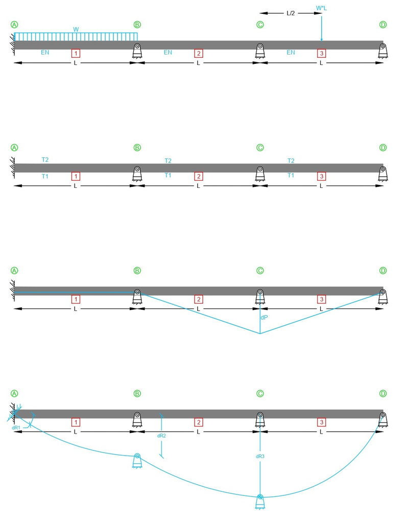

#### Data

```python
w = 2                       # T/m
L = 4                       # m
vb = 0.30                   # m
vh = 0.30                   # m
E = 2100000                 # T/m2
T1 = 9                      # celcius
T2 = 18                     # celcius
alfa = 9.9e-6               # m/m/celcius
dP = 0.008                  # previus deformation
dR1 = 0.001                 # rad
dR2 = 0.009                 # m
dR3 = 0.012                 # m

#------- Geometry---------
XF = np.array([0, L/2, 0.99*L, 1.01*L, L + L/2, L + 0.99*L, L + 1.01*L, 2*L + L/2, 3*L])
YF = np.zeros(len(XF))

XV = np.array([0, L/2, 1.00*L, 1.00*L, L + L/2, L + 1.00*L, L + 1.00*L, 2*L + 1.00*L/2, 2*L + 1.00*L/2, 3*L])
YV = np.zeros(len(XV))
```

#### Calculations

```python
I = vb*vh**3 / 12
```

### Antes de aplicar la matriz de flexibilidad, es importante recordar cómo es nuestra **Estructura Real**

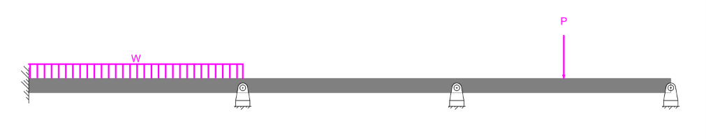

### Así como la manera en que se analizará la misma

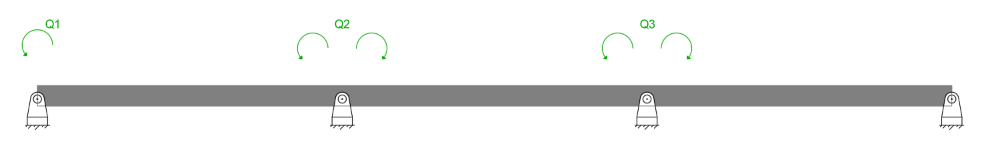

## **Flex Matrix**

$$\Delta = \int_{0}^{L} \frac{M_l \cdot M_u}{EI} \, dx$$

Donde:

- $M_l = 1$
- $M_u = 1$
- $E$ = Módulo de elasticidad
- $I$ = Momento de inercia

## **Caso 1:**

$Q_1 = 1$, $Q_2 = 0$, $Q_3 = 0$

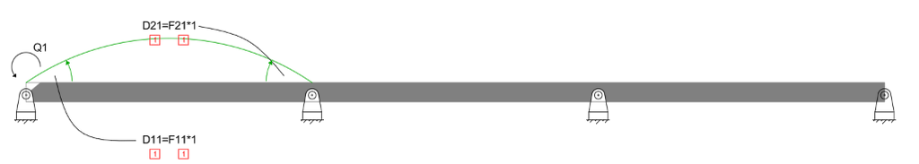

#### Aplicando el principio del trabajo virtual, es decir, la ecuación del diagrama de flexión debido a una carga real en un sistema libre o isostático ($M_L$):

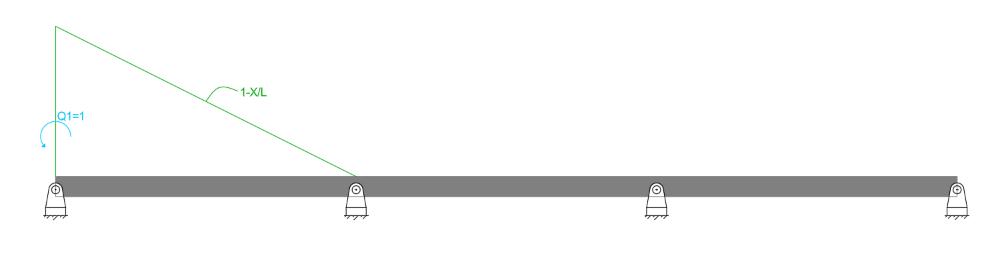

#### También, la ecuación del diagrama de flexión debido a una carga Unitaria en un sistema libre o isostático ($M_U$):

#### Coeficiente de Flexibilidad correspondiente a 1 debido a 1 del elemento 1

($F_{11}[1]$)

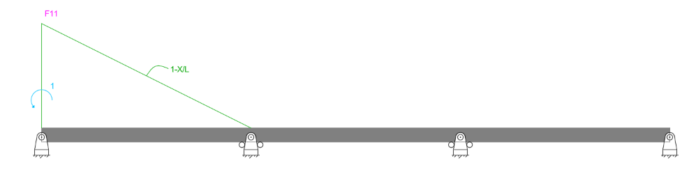

$$F_{11} = \int_{0}^{L} \frac{\left(1 - \frac{x}{L}\right)^2}{EI} \, dx$$

$$F_{11} = \frac{1}{EI} \int_{0}^{L} \left(1 - \frac{x}{L}\right)^2 dx$$

$$F_{11} = \frac{1}{EI} \int_{0}^{L} \left(1 - \frac{2x}{L} + \frac{x^2}{L^2}\right) dx$$

$$F_{11} = \frac{1}{EI} \left[ x - \frac{x^2}{L} + \frac{x^3}{3L^2} \right]_{0}^{L}$$

$$F_{11} = \frac{1}{EI} \left( L - \frac{L^2}{L} + \frac{L^3}{3L^2} \right)$$

$$F_{11} = \frac{1}{EI} \left( L - L + \frac{L}{3} \right)$$

$$F_{11} = \frac{1}{EI} \cdot \frac{L}{3}$$

$$\boxed{F_{11} = \frac{L}{3EI}}$$

#### Coeficiente de Flexibilidad correspondiente a 2 debido a 1 del elemento 1

($F_{21}[1]$)

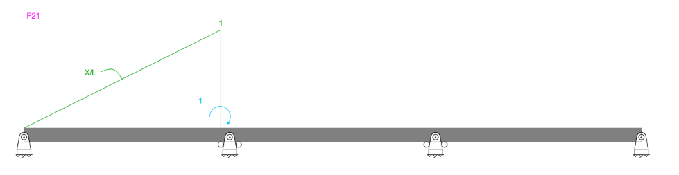

$$-F_{21} = \int_{0}^{L} \frac{\left(1 - \frac{x}{L}\right)\left(\frac{x}{L}\right)}{EI} \, dx$$

$$-F_{21} = \frac{1}{EI} \int_{0}^{L} \left(\frac{x}{L} - \frac{x^2}{L^2}\right) dx$$

$$-F_{21} = \frac{1}{EI} \left[ \frac{x^2}{2L} - \frac{x^3}{3L^2} \right]_{0}^{L}$$

$$-F_{21} = \frac{1}{EI} \left( \frac{L^2}{2L} - \frac{L^3}{3L^2} \right)$$

$$-F_{21} = \frac{1}{EI} \left( \frac{L}{2} - \frac{L}{3} \right)$$

$$-F_{21} = \frac{1}{EI} \cdot \frac{L}{6}$$

$$\boxed{-F_{21} = \frac{L}{6EI}}$$

### Entonces, para el Caso 1 cuando $Q_1 = 1$ su matriz es:

$$ \begin{bmatrix} f_{11} \\ f_{21} \\ f_{31} \end{bmatrix} = \begin{bmatrix} f_{11}\cdot 1 + 0 + 0 \\ f_{21}\cdot 1 + 0 + 0 \\ 0 + 0 + 0 \end{bmatrix} \rightarrow \begin{cases} f_{11} = \dfrac{L}{3EI} \\[10pt] f_{21} = -\dfrac{L}{6EI} \\[10pt] f_{31} = 0 \end{cases} $$

## **Caso 2:**

$Q_2 = 1$, $Q_1 = 0$, $Q_3 = 0$

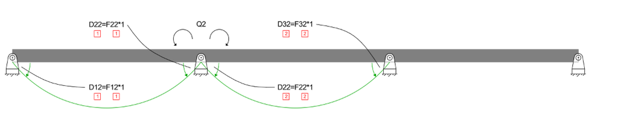

#### Aplicando el principio del trabajo virtual, es decir, la ecuación del diagrama de flexión debido a una carga real en un sistema libre o isostático ($M_L$):

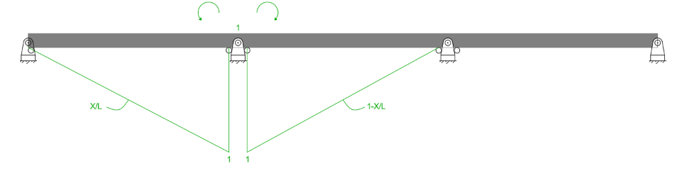

#### También, la ecuación del diagrama de flexión debido a una carga Unitaria en un sistema libre o isostático ($M_U$):

#### Coeficiente de Flexibilidad correspondiente a 1 debido a 2 del elemento 1

($F_{12}[1]$)

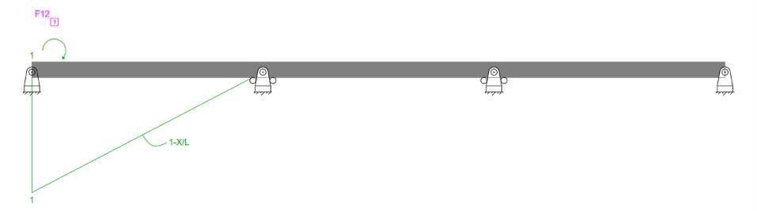

$$-F_{12} [1] = \int_{0}^{L} \frac{\left(\frac{x}{L}\right)\left(1 - \frac{x}{L}\right)}{EI} \, dx$$

$$-F_{12}[1] = \frac{1}{EI} \int_{0}^{L} \left(\frac{x}{L} - \frac{x^2}{L^2}\right) dx$$

$$-F_{12}[1] = \frac{1}{EI} \left[ \frac{x^2}{2L} - \frac{x^3}{3L^2} \right]_{0}^{L}$$

$$-F_{12}[1] = \frac{1}{EI} \left( \frac{L^2}{2L} - \frac{L^3}{3L^2} \right)$$

$$-F_{12}[1] = \frac{1}{EI} \left( \frac{L}{2} - \frac{L}{3} \right)$$

$$-F_{12}[1] = \frac{1}{EI} \cdot \frac{L}{6}$$

$$\boxed{-F_{12}[1] = \frac{L}{6EI}}$$

#### Coeficiente de Flexibilidad correspondiente a 2 debido a 2 del elemento 1

($F_{22}[1]$)

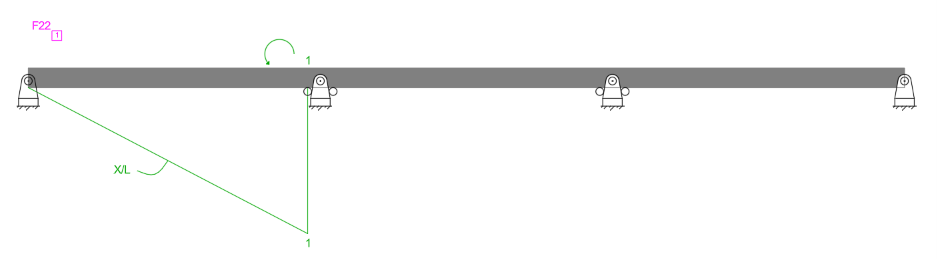

$$F_{22}[1] = \int_{0}^{L} \frac{\left(\frac{x}{L}\right)\left(\frac{x}{L}\right)}{EI} \, dx$$

$$F_{22}[1] = \frac{1}{EI} \int_{0}^{L} \frac{x^2}{L^2} \, dx$$

$$F_{22}[1] = \frac{1}{EI} \left[ \frac{x^3}{3L^2} \right]_{0}^{L}$$

$$F_{22}[1] = \frac{1}{EI} \left( \frac{L^3}{3L^2} \right)$$

$$F_{22}[1] = \frac{1}{EI} \cdot \frac{L}{3}$$

$$\boxed{F_{22}[1] = \frac{L}{3EI}}$$

#### Coeficiente de Flexibilidad correspondiente a 2 debido a 2 del elemento 2

($F_{22}[2]$)

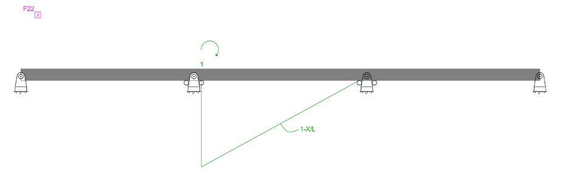

$$F_{22}[2] = \int_{0}^{L} \frac{\left(1 - \frac{x}{L}\right)\left(1 - \frac{x}{L}\right)}{EI} \, dx$$

$$F_{22}[2] = \frac{1}{EI} \int_{0}^{L} \left(1 - \frac{x}{L}\right)^2 dx$$

$$F_{22}[2] = \frac{1}{EI} \int_{0}^{L} \left(1 - \frac{2x}{L} + \frac{x^2}{L^2}\right) dx$$

$$F_{22}[2] = \frac{1}{EI} \left[ x - \frac{x^2}{L} + \frac{x^3}{3L^2} \right]_{0}^{L}$$

$$F_{22}[2] = \frac{1}{EI} \left( L - \frac{L^2}{L} + \frac{L^3}{3L^2} \right)$$

$$F_{22}[2] = \frac{1}{EI} \left( L - L + \frac{L}{3} \right)$$

$$F_{22}[2] = \frac{1}{EI} \cdot \frac{L}{3}$$

$$\boxed{F_{22}[2] = \frac{L}{3EI}}$$

#### Coeficiente de Flexibilidad correspondiente a 3 debido a 2 del elemento 2

($F_{32}[2]$)

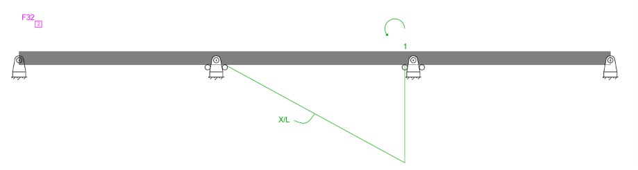

$$F_{32}[2] = \int_{0}^{L} \frac{\left(1 - \frac{x}{L}\right)\left(\frac{x}{L}\right)}{EI} \, dx$$

$$F_{32}[2] = \frac{1}{EI} \int_{0}^{L} \left(\frac{x}{L} - \frac{x^2}{L^2}\right) dx$$

$$F_{32}[2] = \frac{1}{EI} \left[ \frac{x^2}{2L} - \frac{x^3}{3L^2} \right]_{0}^{L}$$

$$F_{32}[2] = \frac{1}{EI} \left( \frac{L^2}{2L} - \frac{L^3}{3L^2} \right)$$

$$F_{32}[2] = \frac{1}{EI} \left( \frac{L}{2} - \frac{L}{3} \right)$$

$$F_{32}[2] = \frac{1}{EI} \cdot \frac{L}{6}$$

$$\boxed{F_{32}[2] = \frac{L}{6EI}}$$

### Entonces, para el Caso 2 cuando $Q_2 = 1$ su matriz es:

$$ \begin{bmatrix} f_{12} \\ f_{22} \\ f_{32} \end{bmatrix} = \begin{bmatrix} 0 + f_{12}\cdot 1 + 0 \\ f_{22}\cdot 1 + f_{22}\cdot 1 + 0 \\ 0 + f_{32}\cdot 1 + 0 \end{bmatrix} \rightarrow \begin{cases} f_{12} = -\dfrac{L}{6EI} \\[10pt] f_{22} = \dfrac{L}{3EI} + \dfrac{L}{3EI} = \dfrac{2L}{3EI} \\[10pt] f_{32} = \dfrac{L}{6EI} \end{cases} $$

## **Caso 3:**

$Q_3 = 1$, $Q_1 = 0$, $Q_2 = 0$

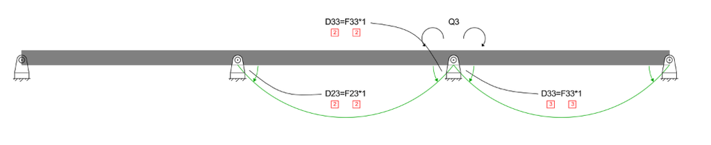

#### Aplicando el principio del trabajo virtual, es decir, la ecuación del diagrama de flexión debido a una carga real en un sistema libre o isostático ($M_L$):

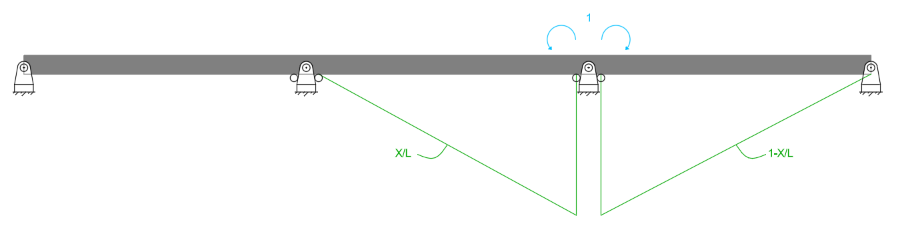

#### También, la ecuación del diagrama de flexión debido a una carga Unitaria en un sistema libre o isostático ($M_U$):

#### Coeficiente de Flexibilidad correspondiente a 2 debido a 3 del elemento 2

($F_{23}[2]$)

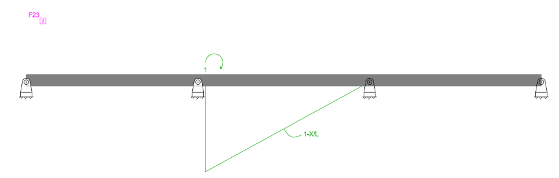

#### Coeficiente de Flexibilidad correspondiente a 3 debido a 3 del elemento 2

($F_{33}[2]$)

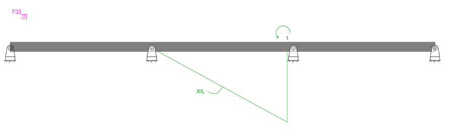

$$ \begin{aligned} F_{33}[2] &= \int_{0}^{L} \frac{\left(\frac{x}{L}\right) \left(\frac{x}{L}\right)}{EI} dx \\[10pt] F_{33}[2] &= \frac{1}{EI} \int_{0}^{L} \left( \frac{x^2}{L^2} \right) dx \\[10pt] F_{33}[2] &= \frac{1}{EI} \left[ \frac{x^3}{3L^2} \right]_{0}^{L} \\[10pt] F_{33}[2] &= \frac{1}{EI} \left( \frac{L^3}{3L^2} \right) \\[10pt] F_{33}[2] &= \frac{1}{EI} \cdot \frac{L}{3} \end{aligned} $$

$$ \boxed{ F_{33}[2] = \frac{L}{3EI} } $$

#### Coeficiente de Flexibilidad correspondiente a 3 debido a 3 del elemento 3

($F_{33}[3]$)

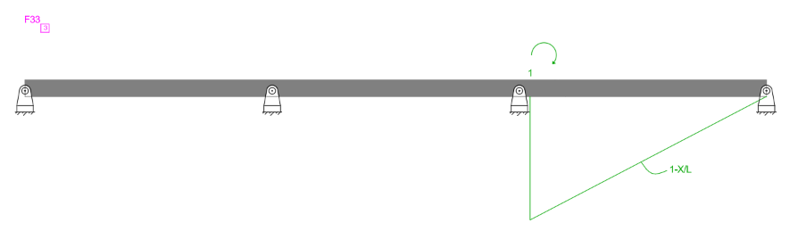

$$ \begin{aligned} F_{33}[3] &= \int_{0}^{L} \frac{\left(1 - \frac{x}{L}\right) \left(1 - \frac{x}{L}\right)}{EI} dx \\[10pt] F_{33}[3] &= \frac{1}{EI} \int_{0}^{L} \left( 1 - \frac{x}{L} \right)^2 dx \\[10pt] F_{33}[3] &= \frac{1}{EI} \int_{0}^{L} \left( 1 - \frac{2x}{L} + \frac{x^2}{L^2} \right) dx \\[10pt] F_{33}[3] &= \frac{1}{EI} \left[ x - \frac{x^2}{L} + \frac{x^3}{3L^2} \right]_{0}^{L} \\[10pt] F_{33}[3] &= \frac{1}{EI} \left( L - \frac{L^2}{L} + \frac{L^3}{3L^2} \right) \\[10pt] F_{33}[3] &= \frac{1}{EI} \left( L - L + \frac{L}{3} \right) \\[10pt] F_{33}[3] &= \frac{1}{EI} \cdot \frac{L}{3} \end{aligned} $$

$$ \boxed{ F_{33}[3] = \frac{L}{3EI} } $$

### Entonces, para el Caso 3 cuando $Q_3 = 1$ su matriz es:

$$ \begin{bmatrix} f_{13} \\ f_{23} \\ f_{33} \end{bmatrix} = \begin{bmatrix} 0 + 0 + f_{13}\cdot 1 \\ 0 + f_{23}\cdot 1 + 0 \\ 0 + f_{33}\cdot 1 + f_{33}\cdot 1 \end{bmatrix} \rightarrow \begin{cases} f_{13} = 0 \\[10pt] f_{23} = \dfrac{L}{6EI} \\[10pt] f_{33} = \dfrac{L}{3EI} + \dfrac{L}{3EI} = \dfrac{2L}{3EI} \end{cases} $$

### La matriz de Flexibilidad queda expresada de la siguiente manera

$$ F = \begin{bmatrix} f_{11} & -f_{12} & f_{13} \\ -f_{21} & f_{22} & f_{23} \\ f_{31} & f_{32} & f_{33} \end{bmatrix} $$

### Por lo tanto, la matriz de flexibilidad, es igual a

$$ F = \begin{bmatrix} \dfrac{L}{3EI} & -\dfrac{L}{6EI} & 0 \\[10pt] -\dfrac{L}{6EI} & \dfrac{2L}{3EI} & \dfrac{L}{6EI} \\[10pt] 0 & \dfrac{L}{6EI} & \dfrac{2L}{3EI} \end{bmatrix} $$

```python
F11 = L / (3*E*I)
F21 = -L / (6*E*I)
F31 = 0
F12 = F21
F22 = 2*L / (3*E*I)
F32 = L / (6*E*I)
F13 = F31
F23 = F32
F33 = 2*L / (3*E*I)

F = np.array([[F11, F12, F13],
              [F21, F22, F23],
              [F31, F32, F33]])

F_df = pd.DataFrame(F, columns=['Q1','Q2','Q3'], index = ['Q1','Q2','Q3'])
F_df
```

|  | Q1 | Q2 | Q3 |
| --- | --- | --- | --- |
| Q1 | 0.000941 | -0.000470 | 0.000000 |
| Q2 | -0.000470 | 0.001881 | 0.000470 |
| Q3 | 0.000000 | 0.000470 | 0.001881 |

##### Displacement vector corresponding to the redundants in the real structure $\{D_Q\}$

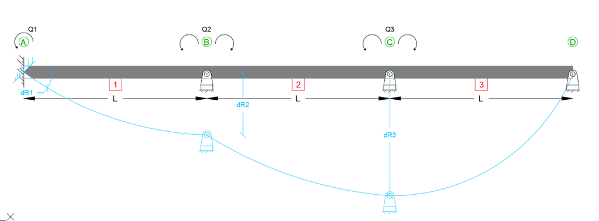

$$ \{\Delta Q\} = \begin{bmatrix} -dRI \\ 0 \\ 0 \end{bmatrix}_{3\times 1} \leftarrow \begin{matrix} Q_1 \\ Q_2 \\ Q_3 \end{matrix} $$

### Código:

```python
DQ = np.array([[-dR1],
               [0],
               [0]])

DQ_df = pd.DataFrame(DQ, columns=['DQ'], index = ['Q1','Q2','Q3'])
DQ_df
```

|  | DQ |
| --- | --- |
| Q1 | -0.001 |
| Q2 | 0.000 |
| Q3 | 0.000 |

##### Displacement vector corresponding to the redundants due to real loads in the released or statically determinate structure

$$ \{D_{QL}\} = \left\{ \begin{matrix} -\frac{wL^3}{24EI} \\[15pt] \frac{wL^3}{24EI} \\[15pt] \frac{wL^3}{16EI} \end{matrix} \right\} $$

```python
DQL = np.array([[-w*L**3 / (24*E*I)],
                [w*L**3 / (24*E*I)],
                [w*L**3 / (16*E*I)]])

DQL_df = pd.DataFrame(DQL, columns=['DQL'], index = ['Q1','Q2','Q3'])
DQL_df
```

|  | DQL |
| --- | --- |
| Q1 | -0.003762 |
| Q2 | 0.003762 |
| Q3 | 0.005644 |

##### Displacement vector corresponding to the redundants due to temperature effects in the released or statically determinate structure

$$ \{D_{QT}\} = \left( \frac{\alpha(T_1 - T_2)}{h} \right) \left\{ \begin{matrix} -\frac{L}{2} \\[15pt] L \\[15pt] L \end{matrix} \right\} $$

```python
DQT = L /2 * (alfa*(T1-T2)) / vh * np.array([[-1],
                                             [2],
                                             [2]])

DQT_df = pd.DataFrame(DQT, columns=['DQT'], index = ['Q1','Q2','Q3'])
DQT_df
```

|  | DQT |
| --- | --- |
| Q1 | 0.000594 |
| Q2 | -0.001188 |
| Q3 | -0.001188 |

##### Displacement vector corresponding to the redundants due to initial deformations in the released or statically determinate structure

$$ \{D_{QP}\} = \left\{ \begin{matrix} 0 \\[15pt] \frac{d_p}{L} \\[15pt] -\frac{2d_p}{L} \end{matrix} \right\} $$

```python
DQP = np.array([[0],
                [dP/L],
                [-2*dP/L]])

DQP_df = pd.DataFrame(DQP, columns=['DQP'], index = ['Q1','Q2','Q3'])
DQP_df
```

|  | DQP |
| --- | --- |
| Q1 | 0.000 |
| Q2 | 0.002 |
| Q3 | -0.004 |

##### Displacement vector corresponding to the redundants due to support displacements in the released or statically determinate structure

$$ \{D_{QR}\} = \begin{bmatrix} -\frac{d_{R2}}{L} & 0 \\[15pt] -\frac{2d_{R2}}{L} & \frac{d_{R3}}{L} \\[15pt] \frac{d_{R2}}{L} & -\frac{2d_{R3}}{L} \end{bmatrix} $$

```python
DQR = np.array([[-dR2/L],
                [-2*dR2/L + dR3/L],
                [dR2/L - 2*dR3/L]])

DQR_df = pd.DataFrame(DQR, columns=['DQR'], index = ['Q1','Q2','Q3'])
DQR_df
```

|  | DQR |
| --- | --- |
| Q1 | -0.00225 |
| Q2 | -0.00150 |
| Q3 | -0.00375 |

#### Total displacement vector corresponding to the redundants in the released or statically determinate structure

$$\{D_{QS}\}= \{D_{QL}\} + \{D_{QT}\} + \{D_{QP}\} + \{D_{QR}\} $$

```python
DQS = DQL + DQT + DQP + DQR

DQS_df = pd.DataFrame(DQS, columns=['DQS'], index = ['Q1','Q2','Q3'])
DQS_df
```

|  | DQS |
| --- | --- |
| Q1 | -0.005418 |
| Q2 | 0.003074 |
| Q3 | -0.003294 |

#### Calculation of redundants

$$\{Q\}=[F]^{-1}\left(\{D_Q\}-\{D_{QS}\}\right) $$

```python
#------------Due all deformations---------------
Q_all = np.linalg.inv(F) @ (DQ - DQS)
Q_all_df = pd.DataFrame(Q_all, columns=['Q due all deformations'])
#------------only due real loads---------------
Q_L = np.linalg.inv(F) @ (0 - DQL)
Q_L_df = pd.DataFrame(Q_L, columns=['Q due real loads'])
#------------only due climate effects---------------
Q_T = np.linalg.inv(F) @ (0 - DQT)
Q_T_df = pd.DataFrame(Q_T, columns=['Q due climate effects'])
#------------only due previus defformations---------------
Q_P = np.linalg.inv(F) @ (0 - DQP)
Q_P_df = pd.DataFrame(Q_P, columns=['Q due previus defformations'])
#------------only due support diplacement---------------
Q_R = np.linalg.inv(F) @ (0 - DQR)
Q_R_df = pd.DataFrame(Q_R, columns=['Q due support diplacement'])

Q = pd.concat([Q_all_df, Q_L_df, Q_T_df, Q_P_df, Q_R_df], axis = 1, ignore_index= False)
Q
```

|  | Q due all deformations | Q due real loads | Q due climate effects | Q due previus defformations | Q due support diplacement |
| --- | --- | --- | --- | --- | --- |
| 0 | 4.144974 | 3.846154 | -0.437190 | -0.981346 | 2.944038 |
| 1 | -1.104872 | -0.307692 | 0.388613 | -1.962692 | 1.104014 |
| 2 | 2.027324 | -2.923077 | 0.534343 | 2.616923 | 1.717356 |

#### Member action vector (flexure) in the real structure

$$\{AM\}= \{AM_L\} + [AM_Q]\{Q\} $$

Where:

- $\{AM\}$ = member action vector (flexure) in the real structure.
- $\{AM_L\}$ = member action vector (flexure) due to real loads in the released or statically determinate structure.
- $[AM_Q]$ = member action matrix (flexure) due to unit redundants in the released or statically determinate structure.
- $\{Q\}$ = vector of redundants.

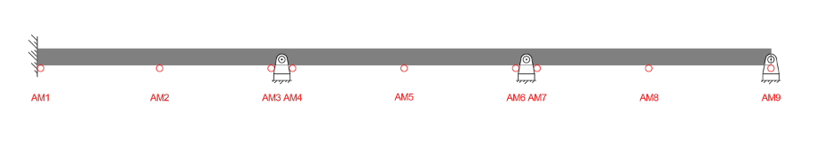

### **Cálculo de momentos aplicando un corte en la estructura**

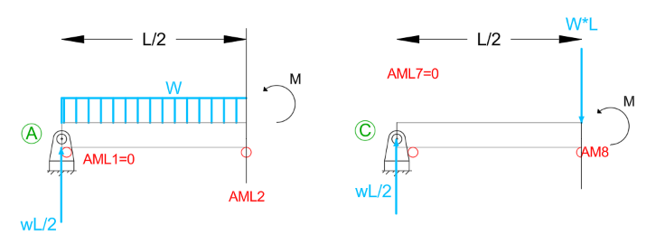

$$ \begin{aligned} \sum M_A &= \frac{wLx}{2} - \frac{wx^2}{2} \\[8pt] M &= \frac{wLx}{2} - \frac{wx^2}{2} \\[8pt] x &= L/2 \\[8pt] M &= \frac{wL^2}{8} \end{aligned} $$

$$ \begin{aligned} \sum M_C &= \frac{wLx}{2} \\[8pt] M &= \frac{wLx}{2} \\[8pt] x &= L/2 \\[8pt] M &= \frac{wL^2}{4} \end{aligned} $$

##### Calculation of Member action vector (flexure) due to real loads in the released or statically determinate structure $\{AML\}$

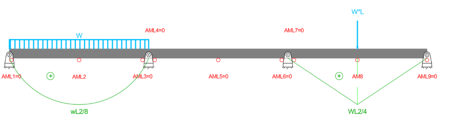

### La matriz ${AML}$ se expresa de la siguiente forma:

$$ {AML} = \begin{bmatrix} 0 \\[6pt] \dfrac{wL^2}{8} \\[6pt] 0 \\[6pt] 0 \\[6pt] 0 \\[6pt] 0 \\[6pt] 0 \\[6pt] \dfrac{wL^2}{4} \\[6pt] 0 \end{bmatrix} $$

### **En código:**

```python
AML = np.array([[0],
                [w*L**(2)/8],
                [0],
                [0],
                [0],
                [0],
                [0],
                [w*L**(2)/4],
                [0],
                ])
```

### Calculation of Member action matrix (flexure) due to unit redundants in the released or statically determinate structure. **$[AMQ]$**

## **Caso 1:**

$Q_1 = 1$, $Q_2 = 0$, $Q_3 = 0$

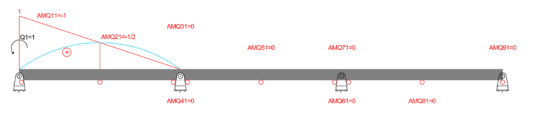

$$ \begin{array}{lcccccc} & \textbf{[1]} & & \textbf{[2]} & & \textbf{[3]} & \\ AMQ_{11} = & (-1) & + & 0 & + & 0 & = -1 \\[8pt] AMQ_{21} = & \left(-\frac{1}{2}\right) & + & 0 & + & 0 & = -\frac{1}{2} \\[8pt] AMQ_{31} = & 0 & + & 0 & + & 0 & = 0 \\[8pt] AMQ_{41} = & 0 & + & 0 & + & 0 & = 0 \\[8pt] AMQ_{51} = & 0 & + & 0 & + & 0 & = 0 \\[8pt] AMQ_{61} = & 0 & + & 0 & + & 0 & = 0 \\[8pt] AMQ_{71} = & 0 & + & 0 & + & 0 & = 0 \\[8pt] AMQ_{81} = & 0 & + & 0 & + & 0 & = 0 \\[8pt] AMQ_{91} = & 0 & + & 0 & + & 0 & = 0 \end{array} $$

## **Caso 2:**

$Q_1 = 0$, $Q_2 = 1$, $Q_3 = 0$

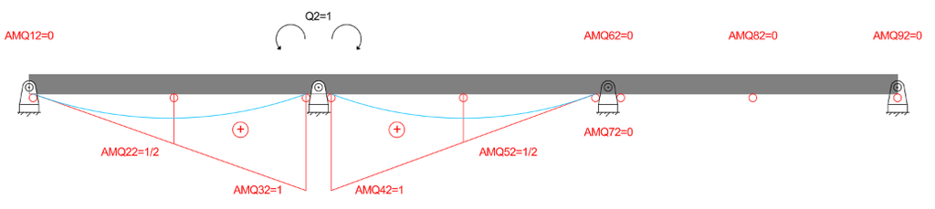

$$ \begin{array}{lcccccc} & \textbf{[1]} & & \textbf{[2]} & & \textbf{[3]} & \\ AMQ_{12} = & 0 & + & 0 & + & 0 & = 0 \\[8pt] AMQ_{22} = & \frac{1}{2} & + & 0 & + & 0 & = \frac{1}{2} \\[8pt] AMQ_{32} = & 1 & + & 0 & + & 0 & = 1 \\[8pt] AMQ_{42} = & 0 & + & 1 & + & 0 & = 1 \\[8pt] AMQ_{52} = & 0 & + & \frac{1}{2} & + & 0 & = \frac{1}{2} \\[8pt] AMQ_{62} = & 0 & + & 0 & + & 0 & = 0 \\[8pt] AMQ_{72} = & 0 & + & 0 & + & 0 & = 0 \\[8pt] AMQ_{82} = & 0 & + & 0 & + & 0 & = 0 \\[8pt] AMQ_{92} = & 0 & + & 0 & + & 0 & = 0 \end{array} $$

## **Caso 3:**

$Q_1 = 0$, $Q_2 = 0$, $Q_3 = 1$

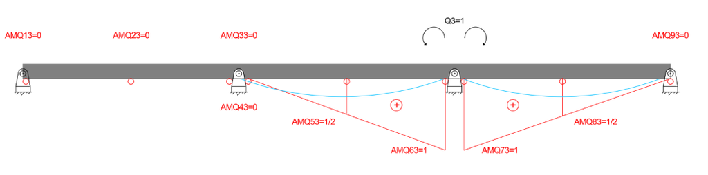

$$ \begin{array}{lcccccc} & \textbf{[1]} & & \textbf{[2]} & & \textbf{[3]} & \\ AMQ_{13} = & 0 & + & 0 & + & 0 & = 0 \\[8pt] AMQ_{23} = & 0 & + & 0 & + & 0 & = 0 \\[8pt] AMQ_{33} = & 0 & + & 0 & + & 0 & = 0 \\[8pt] AMQ_{43} = & 0 & + & 0 & + & 0 & = 0 \\[8pt] AMQ_{53} = & 0 & + & \frac{1}{2} & + & 0 & = \frac{1}{2} \\[8pt] AMQ_{63} = & 0 & + & 1 & + & 0 & = 1 \\[8pt] AMQ_{73} = & 0 & + & 0 & + & 1 & = 1 \\[8pt] AMQ_{83} = & 0 & + & 0 & + & \frac{1}{2} & = \frac{1}{2} \\[8pt] AMQ_{93} = & 0 & + & 0 & + & 0 & = 0 \end{array} $$

### La matriz ${AMQ}$ finalmente resulta:

$$ {AMQ} = \begin{bmatrix} -1 & 0 & 0 \\[6pt] -\frac{1}{2} & \frac{1}{2} & 0 \\[6pt] 0 & 1 & 0 \\[6pt] 0 & 1 & 0 \\[6pt] 0 & \frac{1}{2} & \frac{1}{2} \\[6pt] 0 & 0 & 1 \\[6pt] 0 & 0 & 1 \\[6pt] 0 & 0 & \frac{1}{2} \\[6pt] 0 & 0 & 0 \end{bmatrix} $$

### **En código:**

```python
AMQ = np.array([[-1, 0, 0],
                [-1/2, 1/2, 0],
                [0, 1, 0],
                [0, 1, 0],
                [0, 1/2, 1/2],
                [0, 0, 1],
                [0, 0, 1],
                [0, 0, 1/2],
                [0, 0, 0],
                ])
```

##### Calculation of Member action vector (flexure) in the real structure $\{AM\} = \{AM_L\}+[AM_Q]\{Q\}$.

```python
#------------Due all deformations---------------
AM_all = AML + (AMQ @ Q_all)
AM_all_df = pd.DataFrame(AM_all, columns=['AM due all deformations'])
#------------only due real loads---------------
AM_L = AML + (AMQ @ Q_L)
AM_L_df = pd.DataFrame(AM_L, columns=['AM due real loads'])
#------------only due climate effects---------------
AM_T = AML + (AMQ @ Q_T)
AM_T_df = pd.DataFrame(AM_T, columns=['AM due climate effects'])
#------------only due previus defformations---------------
AM_P = AML + (AMQ @ Q_P)
AM_P_df = pd.DataFrame(AM_P, columns=['AM due previus defformations'])
#------------only due support diplacement---------------
AM_R = AML + (AMQ @ Q_R)
AM_R_df = pd.DataFrame(AM_R, columns=['AM due support displacement'])

AM = pd.concat([AM_all_df, AM_L_df, AM_T_df, AM_P_df, AM_R_df], axis = 1, ignore_index= False)
AM
```

|  | AM due all deformations | AM due real loads | AM due climate effects | AM due previus defformations | AM due support displacement |
| --- | --- | --- | --- | --- | --- |
| 0 | -4.144974 | -3.846154 | 0.437190 | 0.981346 | -2.944038 |
| 1 | 1.375077 | 1.923077 | 4.412901 | 3.509327 | 3.079988 |
| 2 | -1.104872 | -0.307692 | 0.388613 | -1.962692 | 1.104014 |
| 3 | -1.104872 | -0.307692 | 0.388613 | -1.962692 | 1.104014 |
| 4 | 0.461226 | -1.615385 | 0.461478 | 0.327115 | 1.410685 |
| 5 | 2.027324 | -2.923077 | 0.534343 | 2.616923 | 1.717356 |
| 6 | 2.027324 | -2.923077 | 0.534343 | 2.616923 | 1.717356 |
| 7 | 9.013662 | 6.538462 | 8.267171 | 9.308462 | 8.858678 |
| 8 | 0.000000 | 0.000000 | 0.000000 | 0.000000 | 0.000000 |

##### For Plotting - FLEXION

```python
AM_all = AM_all * -1
AM_L = AM_L * -1
AM_T = AM_T * -1
AM_P = AM_P * -1
AM_R = AM_R * -1
```

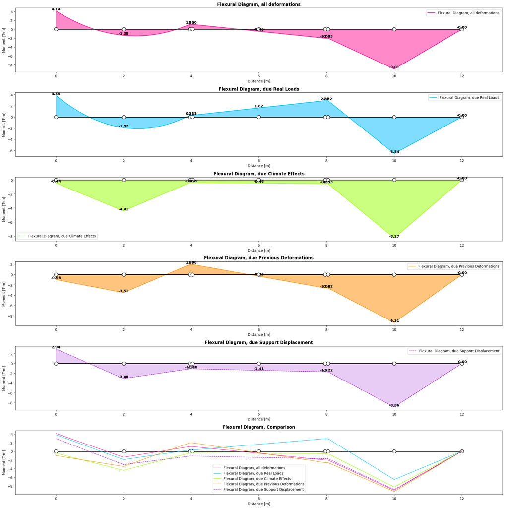

```python
am1 = AM_all.ravel()
am2 = AM_L.ravel()
am3 = AM_T.ravel()
am4 = AM_P.ravel()
am5 = AM_R.ravel()

fig, ax = plt.subplots(6, 1, figsize=(20, 20))
L_ref = XF[-1] - XF[0]

data_list = [
    (am1, (1.0, 0.08, 0.58), 'Flexural Diagram, all deformations',         '-',  0.5),
    (am2, (0.0, 0.75, 1.0),  'Flexural Diagram, due Real Loads',            '-',  0.5),
    (am3, (0.6, 1.0, 0.0),   'Flexural Diagram, due Climate Effects',       '-',  0.5),
    (am4, (1.0, 0.55, 0.0),  'Flexural Diagram, due Previous Deformations', '-',  0.5),
    (am5, (0.58, 0.0, 0.83), 'Flexural Diagram, due Support Displacement',  '--', 0.2),
]

for i, (data, clr, title, style, alpha_val) in enumerate(data_list):
    if i < 2:
        x_spline = XF[:3]
        y_spline = data[:3]
        coefs = np.polyfit(x_spline, y_spline, 2)
        x_fine = np.linspace(x_spline[0], x_spline[-1], 200)
        y_fine = np.polyval(coefs, x_fine)
        ax[i].plot(x_fine, y_fine, color=clr, lw=1.5, ls=style)
        ax[i].fill_between(x_fine, y_fine, color=clr, alpha=alpha_val)
        ax[i].plot(XF[2:], data[2:], color=clr, lw=1.5, ls=style, label=title)
        ax[i].fill_between(XF[2:], data[2:], color=clr, alpha=alpha_val)
    else:
        ax[i].plot(XF, data, color=clr, lw=1, ls=style, label=title)
        ax[i].fill_between(XF, data, color=clr, alpha=alpha_val)

    ax[i].plot(XF, YF, color=(0,0,0), lw=2, ls='-', marker='o', markersize=10, markerfacecolor=(1,1,1))

    for j in range(len(XF)):
        ax[i].text(XF[j], data[j], f'{data[j]:.2f}', fontsize=10, fontweight='bold', ha='center', va='bottom')

    ax[i].set_title(title, fontsize=12, fontweight='bold')
    ax[i].set_xlabel('Distance [m]')
    ax[i].set_ylabel('Moment [T-m]')
    ax[i].set_xlim([XF[0] - L_ref*0.1, XF[-1] + L_ref*0.1])
    ax[i].legend()

# COMPARISON
ax[5].plot(XF, YF, color=(0,0,0), lw=2, ls='-', marker='o', markersize=10, markerfacecolor=(1,1,1))
for (data, clr, title, style, _) in data_list:
    ax[5].plot(XF, data, color=clr, lw=1, ls=style, marker='None', label=title)

ax[5].set_title('Flexural Diagram, Comparison', fontsize=12, fontweight='bold')
ax[5].set_xlabel('Distance [m]')
ax[5].set_ylabel('Moment [T-m]')
ax[5].set_xlim([XF[0] - L_ref*0.1, XF[-1] + L_ref*0.1])
ax[5].legend()

plt.tight_layout()
plt.show()
```

#### Member action vector (Shear) in the real structure

$$\{AM\}= \{AM_L\} + [AM_Q]\{Q\} $$

Where:

- $\{AM\}$ = member action vector (Shear) in the real structure.
- $\{AM_L\}$ = member action vector (Shear) due to real loads in the released or statically determinate structure.
- $[AM_Q]$ = member action matrix (Shear) due to unit redundants in the released or statically determinate structure.
- $\{Q\}$ = vector of redundants.

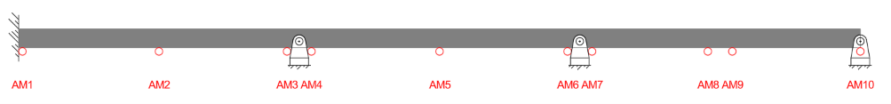

$$ \boldsymbol{\{AM\}_v = \{AML\}_v + [AMQ]_v \cdot \{Q\}} $$

### **Se aplica Estática**

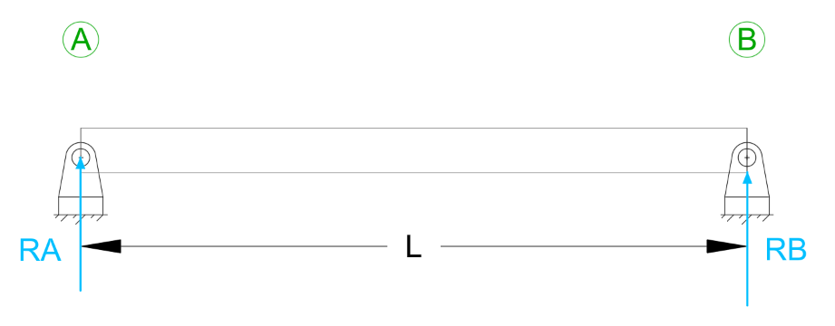

### **Sumatoria de Fuerzas**

$$ \begin{aligned} +\uparrow \sum F &= 0 \\ R_A + R_B &= 0 \\ (1) \quad R_B &= -R_A \end{aligned} $$

### **Sumatoria de Momentos**

$$ \begin{aligned} +\circlearrowleft \sum M_B &= 0 \\ 1 - R_A L &= 0 \\ 1 &= R_A L \\ (2) \quad R_A &= \frac{1}{L} \end{aligned} $$

**(2) en (1)**

$$ R_B = -\frac{1}{L} $$

##### Calculation of Member action vector (Shear) due to real loads in the released or statically determinate structure $\{AML\}$

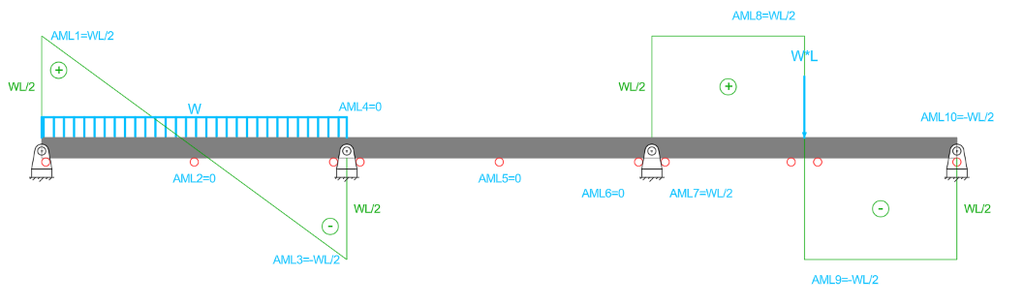

$$ \{AML_v\} = \left\{ \begin{matrix} \frac{wL}{2} \\[12pt] 0 \\[12pt] -\frac{wL}{2} \\[12pt] 0 \\[12pt] 0 \\[12pt] 0 \\[12pt] \frac{wL}{2} \\[12pt] \frac{wL}{2} \\[12pt] -\frac{wL}{2} \\[12pt] -\frac{wL}{2} \end{matrix} \right\} $$

```python
AMLv = np.array([[w*L/2],
                 [0],
                 [-w*L/2],
                 [0],
                 [0],
                 [0],
                 [w*L/2],
                 [w*L/2],
                 [-w*L/2],
                 [-w*L/2]])
```

##### Calculation of Member action matrix (Shear) due to unit redundants in the released or statically determinate structure. $[AM_Q]$

## **Caso 1:**

$Q_1 = 1$, $Q_2 = 0$, $Q_3 = 0$

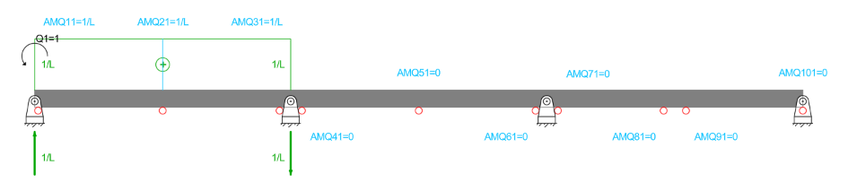

$$ \begin{array}{lcccccc} & \textbf{[1]} & & \textbf{[2]} & & \textbf{[3]} & \\ AMQ_{11} = & \frac{1}{L} & + & 0 & + & 0 & = \frac{1}{L} \\[8pt] AMQ_{21} = & \frac{1}{L} & + & 0 & + & 0 & = \frac{1}{L} \\[8pt] AMQ_{31} = & \frac{1}{L} & + & 0 & + & 0 & = \frac{1}{L} \\[8pt] AMQ_{41} = & 0 & + & 0 & + & 0 & = 0 \\[8pt] AMQ_{51} = & 0 & + & 0 & + & 0 & = 0 \\[8pt] AMQ_{61} = & 0 & + & 0 & + & 0 & = 0 \\[8pt] AMQ_{71} = & 0 & + & 0 & + & 0 & = 0 \\[8pt] AMQ_{81} = & 0 & + & 0 & + & 0 & = 0 \\[8pt] AMQ_{91} = & 0 & + & 0 & + & 0 & = 0 \\[8pt] AMQ_{10 1} = & 0 & + & 0 & + & 0 & = 0 \end{array} $$

## **Caso 2:**

$Q_1 = 0$, $Q_2 = 1$, $Q_3 = 0$

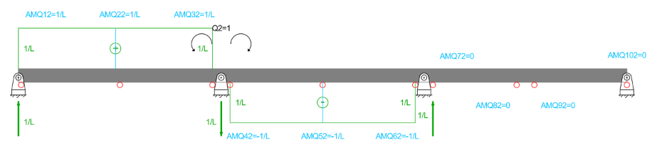

$$ \begin{array}{lcccccc} & \textbf{[1]} & & \textbf{[2]} & & \textbf{[3]} & \\ AMQ_{12} = & \frac{1}{L} & + & 0 & + & 0 & = \frac{1}{L} \\[8pt] AMQ_{22} = & \frac{1}{L} & + & 0 & + & 0 & = \frac{1}{L} \\[8pt] AMQ_{32} = & \frac{1}{L} & + & 0 & + & 0 & = \frac{1}{L} \\[8pt] AMQ_{42} = & 0 & + & \left(-\frac{1}{L}\right) & + & 0 & = -\frac{1}{L} \\[8pt] AMQ_{52} = & 0 & + & \left(-\frac{1}{L}\right) & + & 0 & = -\frac{1}{L} \\[8pt] AMQ_{62} = & 0 & + & \left(-\frac{1}{L}\right) & + & 0 & = -\frac{1}{L} \\[8pt] AMQ_{72} = & 0 & + & 0 & + & 0 & = 0 \\[8pt] AMQ_{82} = & 0 & + & 0 & + & 0 & = 0 \\[8pt] AMQ_{92} = & 0 & + & 0 & + & 0 & = 0 \\[8pt] AMQ_{10 2} = & 0 & + & 0 & + & 0 & = 0 \end{array} $$

## **Caso 3:**

$Q_1 = 0$, $Q_2 = 0$, $Q_3 = 1$

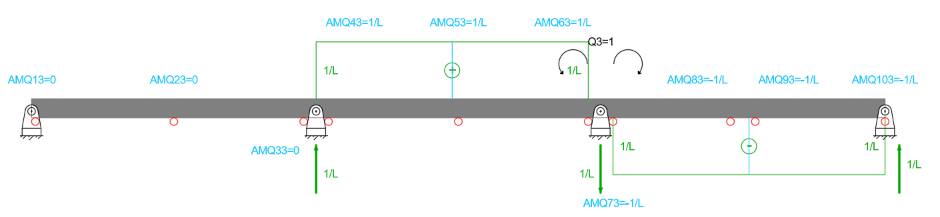

$$ \begin{array}{lcccccc} & \textbf{[1]} & & \textbf{[2]} & & \textbf{[3]} & \\ AMQ_{13} = & 0 & + & 0 & + & 0 & = 0 \\[8pt] AMQ_{23} = & 0 & + & 0 & + & 0 & = 0 \\[8pt] AMQ_{33} = & 0 & + & 0 & + & 0 & = 0 \\[8pt] AMQ_{43} = & 0 & + & \frac{1}{L} & + & 0 & = \frac{1}{L} \\[8pt] AMQ_{53} = & 0 & + & \frac{1}{L} & + & 0 & = \frac{1}{L} \\[8pt] AMQ_{63} = & 0 & + & \frac{1}{L} & + & 0 & = \frac{1}{L} \\[8pt] AMQ_{73} = & 0 & + & 0 & + & \left(-\frac{1}{L}\right) & = -\frac{1}{L} \\[8pt] AMQ_{83} = & 0 & + & 0 & + & \left(-\frac{1}{L}\right) & = -\frac{1}{L} \\[8pt] AMQ_{93} = & 0 & + & 0 & + & \left(-\frac{1}{L}\right) & = -\frac{1}{L} \\[8pt] AMQ_{10 3} = & 0 & + & 0 & + & \left(-\frac{1}{L}\right) & = -\frac{1}{L} \end{array} $$

### La matriz ${AMQ_V}$ finalmente resulta:

$$ [AMQ]_v = \begin{bmatrix} \frac{1}{L} & \frac{1}{L} & 0 \\[10pt] \frac{1}{L} & \frac{1}{L} & 0 \\[10pt] \frac{1}{L} & \frac{1}{L} & 0 \\[10pt] 0 & -\frac{1}{L} & \frac{1}{L} \\[10pt] 0 & -\frac{1}{L} & \frac{1}{L} \\[10pt] 0 & -\frac{1}{L} & \frac{1}{L} \\[10pt] 0 & 0 & -\frac{1}{L} \\[10pt] 0 & 0 & -\frac{1}{L} \\[10pt] 0 & 0 & -\frac{1}{L} \\[10pt] 0 & 0 & -\frac{1}{L} \end{bmatrix} $$

### **En Código**

```python
AMQv = np.array([[1/L, 1/L, 0],
                 [1/L, 1/L, 0],
                 [1/L, 1/L, 0],
                 [0, -1/L, 1/L],
                 [0, -1/L, 1/L],
                 [0, -1/L, 1/L],
                 [0, 0, -1/L],
                 [0, 0, -1/L],
                 [0, 0, -1/L],
                 [0, 0, -1/L]])
```

##### Calculation of Member action vector (Shear) in the real structure $\{AM\} = \{AM_L\}+[AM_Q]\{Q\}$.

```python
#------------Due all deformations---------------
AMv_all = AMLv + (AMQv @ Q_all)
AMv_all_df = pd.DataFrame(AMv_all, columns=['AMv due all deformations'])
#------------only due real loads---------------
AMv_L = AMLv + (AMQv @ Q_L)
AMv_L_df = pd.DataFrame(AMv_L, columns=['AMv due real loads'])
#------------only due climate effects---------------
AMv_T = AMLv + (AMQv @ Q_T)
AMv_T_df = pd.DataFrame(AMv_T, columns=['AMv due climate effects'])
#------------only due previus defformations---------------
AMv_P = AMLv + (AMQv @ Q_P)
AMv_P_df = pd.DataFrame(AMv_P, columns=['AMv due previus defformations'])
#------------only due support diplacement---------------
AMv_R = AMLv + (AMQv @ Q_R)
AMv_R_df = pd.DataFrame(AMv_R, columns=['AMv due support displacement'])

AMv = pd.concat([AMv_all_df, AMv_L_df, AMv_T_df, AMv_P_df, AMv_R_df], axis = 1, ignore_index= False)
AMv
```

|  | AMv due all deformations | AMv due real loads | AMv due climate effects | AMv due previus defformations | AMv due support displacement |
| --- | --- | --- | --- | --- | --- |
| 0 | 4.760025 | 4.884615 | 3.987856 | 3.263990 | 5.012013 |
| 1 | 0.760025 | 0.884615 | -0.012144 | -0.736010 | 1.012013 |
| 2 | -3.239975 | -3.115385 | -4.012144 | -4.736010 | -2.987987 |
| 3 | 0.783049 | -0.653846 | 0.036432 | 1.144904 | 0.153335 |
| 4 | 0.783049 | -0.653846 | 0.036432 | 1.144904 | 0.153335 |
| 5 | 0.783049 | -0.653846 | 0.036432 | 1.144904 | 0.153335 |
| 6 | 3.493169 | 4.730769 | 3.866414 | 3.345769 | 3.570661 |
| 7 | 3.493169 | 4.730769 | 3.866414 | 3.345769 | 3.570661 |
| 8 | -4.506831 | -3.269231 | -4.133586 | -4.654231 | -4.429339 |
| 9 | -4.506831 | -3.269231 | -4.133586 | -4.654231 | -4.429339 |